# LME Analysis of NUCs

## Truncation and Compression Effects

NB: only foot_syls is of interest here, not pre-syls or fin-phon However, to preserve previous models, they are included as fixed effects, but they are discarded.

### LH Excursion

- model needs trimming (|sd| residuals > 3.5)

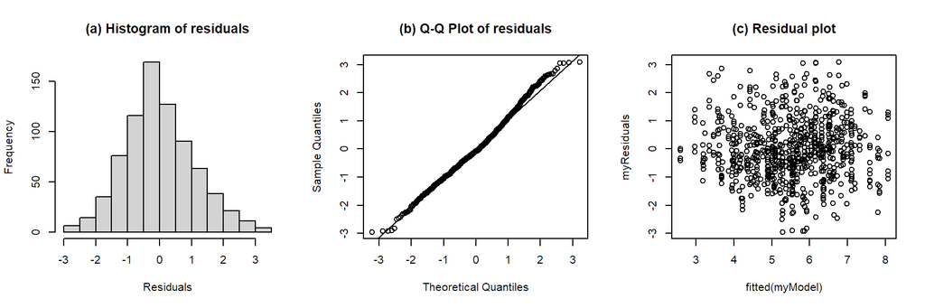

```
## Formula:  f0_exc ~ foot_syls + pre_syls + fin_phon + (1 | speaker) + (1 | nuc_pre_text)
##
## Linear mixed model fit by REML. t-tests use Satterthwaite's method [
## lmerModLmerTest]
## Formula: f0_exc_equation
##    Data: nuc_f0_exc.trimmed
## Control:
## lmerControl(optimizer = optimizer, calc.derivs = FALSE, optCtrl = list(method = "nlminb",
##     starttests = FALSE, kkt = FALSE))
##
## REML criterion at convergence: 2405.6
##
## Scaled residuals:
##      Min       1Q   Median       3Q      Max
## -2.66763 -0.65171 -0.07356  0.62565  2.79375
##
## Random effects:
##  Groups       Name        Variance Std.Dev.
##  nuc_pre_text (Intercept) 0.4715   0.6867
##  speaker      (Intercept) 0.8562   0.9253
##  Residual                 1.2186   1.1039
## Number of obs: 770, groups:  nuc_pre_text, 12; speaker, 11
##
## Fixed effects:
##             Estimate Std. Error       df t value Pr(>|t|)
## (Intercept)   4.1633     0.7531   7.6507   5.528 0.000648 ***
## foot_syls2    0.4030     0.9921   5.8470   0.406 0.699045
## foot_syls3    1.9163     0.1601 746.0583  11.966  < 2e-16 ***
## foot_syls4    0.9489     0.9924   5.8546   0.956 0.376780
## pre_syls1     0.6055     0.9844   5.6682   0.615 0.562353
## pre_syls2     1.2453     1.2594   5.7513   0.989 0.362525
## pre_syls3     1.1502     1.2597   5.7550   0.913 0.397812
## fin_phonL%   -0.8187     0.2546 750.7432  -3.215 0.001358 **
## ---
## Signif. codes:  0 '***' 0.001 '**' 0.01 '*' 0.05 '.' 0.1 ' ' 1
##
## Correlation of Fixed Effects:
##            (Intr) ft_sy2 ft_sy3 ft_sy4 pr_sy1 pr_sy2 pr_sy3
## foot_syls2 -0.007
## foot_syls3 -0.106  0.065
```

[output cut: 16 more lines]

```
##
## Backward reduced fixed-effect table:
## Degrees of freedom method: Satterthwaite
##
##           Eliminated  Sum Sq Mean Sq NumDF  DenDF F value    Pr(>F)
## pre_syls           1   1.275   0.425     3   5.82  0.3488  0.791942
## foot_syls          0 174.879  58.293     3  12.34 47.8332 4.594e-07 ***
## fin_phon           0  12.517  12.517     1 751.78 10.2707  0.001409 **
## ---
## Signif. codes:  0 '***' 0.001 '**' 0.01 '*' 0.05 '.' 0.1 ' ' 1
##
## Model found:
## f0_exc ~ foot_syls + fin_phon + (1 | speaker) + (1 | nuc_pre_text)
##
## isSingular(my_model, tol = 1e-05 ) --> FALSE
```

Anova of model: f0_exc ~ foot_syls + pre_syls + fin_phon + (1 | speaker) + (1 | nuc_pre_text)

| term | sumsq | meansq | NumDF | DenDF | F value | p.value | signif. |
| --- | --- | --- | --- | --- | --- | --- | --- |
| foot_syls | 174.866 | 58.289 | 3 | 7.786 | 47.832 | 2.297266e-05 | p<0.001 |
| pre_syls | 1.275 | 0.425 | 3 | 5.817 | 0.349 | 7.919419e-01 |  |
| fin_phon | 12.599 | 12.599 | 1 | 750.743 | 10.339 | 1.358479e-03 | p<0.01 |

Conditional and marginal R<sup>2</sup> of model

| R2_conditional | R2_marginal |
| --- | --- |
| 0.57 | 0.11 |

$foot_syls

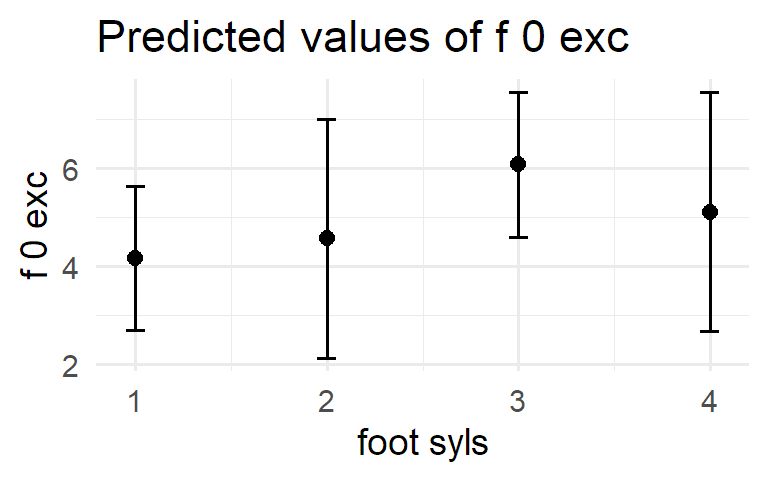

$pre_syls

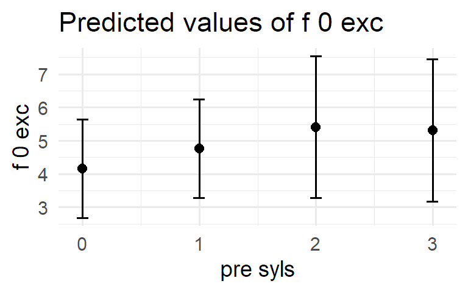

$fin_phon

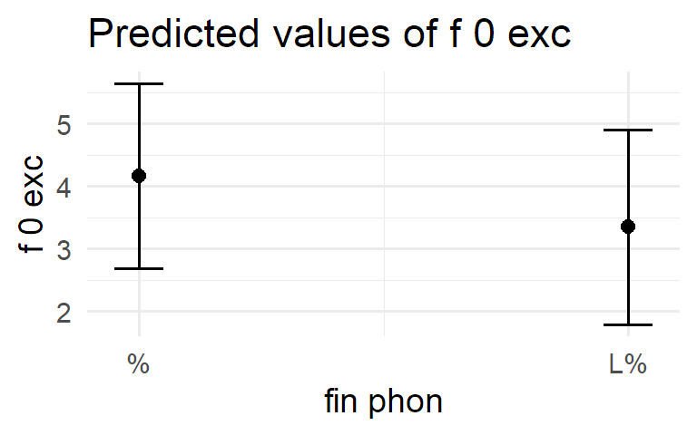

summary of model: f0_exc ~ foot_syls + pre_syls + fin_phon + (1 | speaker) + (1 | nuc_pre_text)

| term | estimate | conf.low | conf.high | std.error | t.value | df | p.value |
| --- | --- | --- | --- | --- | --- | --- | --- |
| (Intercept) | 4.163 | 2.412842 | 5.9138523 | 0.753 | 5.528 | 7.65 | 6e-04 |
| foot_syls2 | 0.403 | -2.040006 | 2.8459554 | 0.992 | 0.406 | 5.85 | 0.699 |
| foot_syls3 | 1.916 | 1.601888 | 2.2306389 | 0.160 | 11.966 | 746.06 | 2.6e-30 |
| foot_syls4 | 0.949 | -1.494080 | 3.3918836 | 0.992 | 0.956 | 5.85 | 0.3768 |
| pre_syls1 | 0.605 | -1.837828 | 3.0488207 | 0.984 | 0.615 | 5.67 | 0.5624 |
| pre_syls2 | 1.245 | -1.869013 | 4.3596313 | 1.259 | 0.989 | 5.75 | 0.3625 |
| pre_syls3 | 1.150 | -1.964126 | 4.2645953 | 1.260 | 0.913 | 5.75 | 0.3978 |
| fin_phonL% | -0.819 | -1.318602 | -0.3188612 | 0.255 | -3.215 | 750.74 | 0.0014 |

b0 for f0_exc ~ foot_syls + pre_syls + fin_phon + (1 | speaker) + (1 | nuc_pre_text)

| intercept | estimate | conf.low | conf.high | std.error | t.value | df | p.value |
| --- | --- | --- | --- | --- | --- | --- | --- |
| foot_syls1 | 4.163 | 2.413 | 5.914 | 0.753 | 5.528 | 7.65 | 6.5e-04 |
| foot_syls2 | 4.566 | 1.57 | 7.563 | 1.241 | 3.679 | 6.36 | 0.009 |
| foot_syls3 | 6.08 | 4.329 | 7.83 | 0.753 | 8.073 | 7.65 | 5.3e-05 |
| foot_syls4 | 5.112 | 2.116 | 8.109 | 1.242 | 4.118 | 6.36 | 0.005 |

b1 for f0_exc ~ foot_syls + pre_syls + fin_phon + (1 | speaker) + (1 | nuc_pre_text)

| intercept | slope | estimate | conf.low | conf.high | std.error | t.value | df | p.value |
| --- | --- | --- | --- | --- | --- | --- | --- | --- |
| foot_syls1 | foot_syls2 | 0.403 | -2.04 | 2.846 | 0.992 | 0.406 | 5.85 | 0.699 |
| foot_syls1 | foot_syls3 | 1.916 | 1.602 | 2.231 | 0.160 | 11.966 | 746.06 | 2.6e-30 |
| foot_syls1 | foot_syls4 | 0.949 | -1.494 | 3.392 | 0.992 | 0.956 | 5.85 | 0.377 |
| foot_syls2 | foot_syls3 | 1.513 | -0.93 | 3.956 | 0.995 | 1.521 | 5.91 | 0.18 |
| foot_syls2 | foot_syls4 | 0.546 | -1.897 | 2.989 | 0.994 | 0.549 | 5.90 | 0.603 |
| foot_syls3 | foot_syls4 | -0.967 | -3.41 | 1.476 | 0.995 | -0.972 | 5.91 | 0.369 |

### LH Slope

Based on results from tonal target analysis, it looksl like compression and truncation may be in effect. As compression leads to decrease in duration of rise (but not necessarily much descrease in excursion size), and as slope increases exponentially as duration decreases, slope has been logged here.

- model needs trimming (|sd| residuals > 3.5)

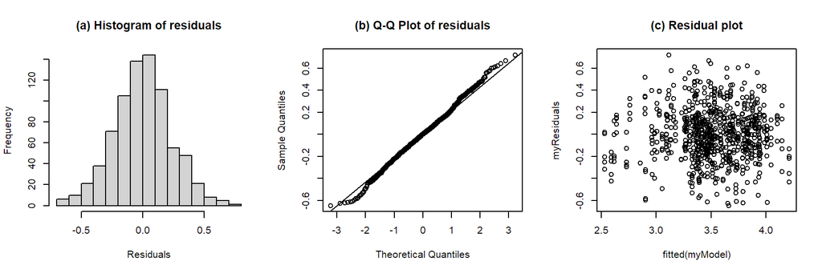

```
## Formula:  log_lh_slope ~ foot_syls + pre_syls + fin_phon + (1 | speaker) + (1 | nuc_pre_text)
##
## Linear mixed model fit by REML. t-tests use Satterthwaite's method [
## lmerModLmerTest]
## Formula: lh_slope_equation
##    Data: nuc_lh_slope.trimmed
## Control:
## lmerControl(optimizer = optimizer, calc.derivs = FALSE, optCtrl = list(method = "nlminb",
##     starttests = FALSE, kkt = FALSE))
##
## REML criterion at convergence: 61.9
##
## Scaled residuals:
##      Min       1Q   Median       3Q      Max
## -2.72077 -0.61863  0.00697  0.60717  3.03265
##
## Random effects:
##  Groups       Name        Variance Std.Dev.
##  nuc_pre_text (Intercept) 0.01200  0.1096
##  speaker      (Intercept) 0.05030  0.2243
##  Residual                 0.05632  0.2373
## Number of obs: 782, groups:  nuc_pre_text, 12; speaker, 11
##
## Fixed effects:
##              Estimate Std. Error        df t value Pr(>|t|)
## (Intercept)   3.32228    0.13195   9.63797  25.178 4.06e-10 ***
## foot_syls2   -0.02335    0.16093   5.72168  -0.145 0.889597
## foot_syls3   -0.12947    0.03447 757.94288  -3.756 0.000186 ***
## foot_syls4   -0.77498    0.16090   5.71735  -4.817 0.003364 **
## pre_syls1     0.27402    0.15878   5.42135   1.726 0.140395
## pre_syls2     0.35936    0.20371   5.56251   1.764 0.132041
## pre_syls3     0.37591    0.20373   5.56456   1.845 0.118389
## fin_phonL%    0.09563    0.05394 763.27174   1.773 0.076648 .
## ---
## Signif. codes:  0 '***' 0.001 '**' 0.01 '*' 0.05 '.' 0.1 ' ' 1
##
## Correlation of Fixed Effects:
##            (Intr) ft_sy2 ft_sy3 ft_sy4 pr_sy1 pr_sy2 pr_sy3
## foot_syls2 -0.012
## foot_syls3 -0.132  0.085
```

[output cut: 16 more lines]

```
##
## Backward reduced fixed-effect table:
## Degrees of freedom method: Satterthwaite
##
##           Eliminated Sum Sq Mean Sq NumDF  DenDF F value    Pr(>F)
## pre_syls           1 0.2038 0.06792     3   5.66  1.2060   0.38887
## fin_phon           2 0.1814 0.18135     1 764.32  3.2201   0.07313 .
## foot_syls          0 3.4396 1.14654     3  12.01 20.3013 5.371e-05 ***
## ---
## Signif. codes:  0 '***' 0.001 '**' 0.01 '*' 0.05 '.' 0.1 ' ' 1
##
## Model found:
## log_lh_slope ~ foot_syls + (1 | speaker) + (1 | nuc_pre_text)
##
## isSingular(my_model, tol = 1e-05 ) --> FALSE
```

Anova of model: log_lh_slope ~ foot_syls + pre_syls + fin_phon + (1 | speaker) + (1 | nuc_pre_text)

| term | sumsq | meansq | NumDF | DenDF | F value | p.value | signif. |
| --- | --- | --- | --- | --- | --- | --- | --- |
| foot_syls | 2.368 | 0.789 | 3 | 7.608 | 14.017 | 0.001797283 | p<0.01 |
| pre_syls | 0.204 | 0.068 | 3 | 5.663 | 1.206 | 0.388873339 |  |
| fin_phon | 0.177 | 0.177 | 1 | 763.272 | 3.143 | 0.076648247 |  |

Conditional and marginal R<sup>2</sup> of model

| R2_conditional | R2_marginal |
| --- | --- |
| 0.68 | 0.33 |

$foot_syls

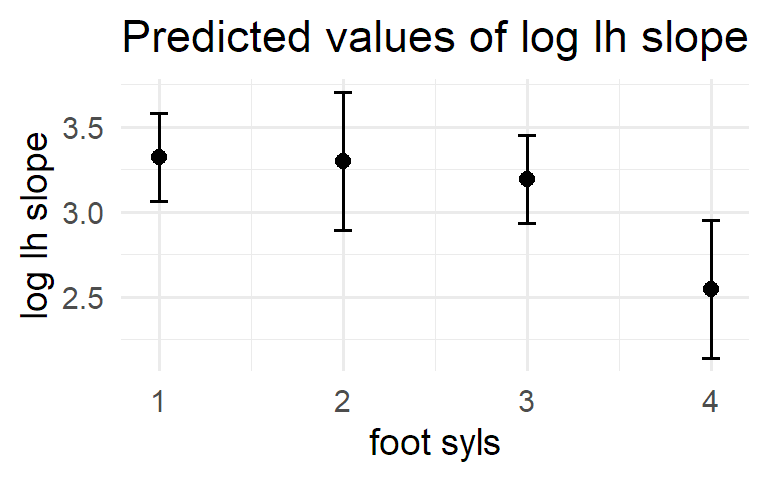

$pre_syls

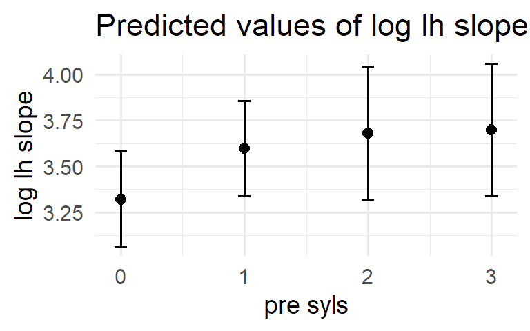

$fin_phon

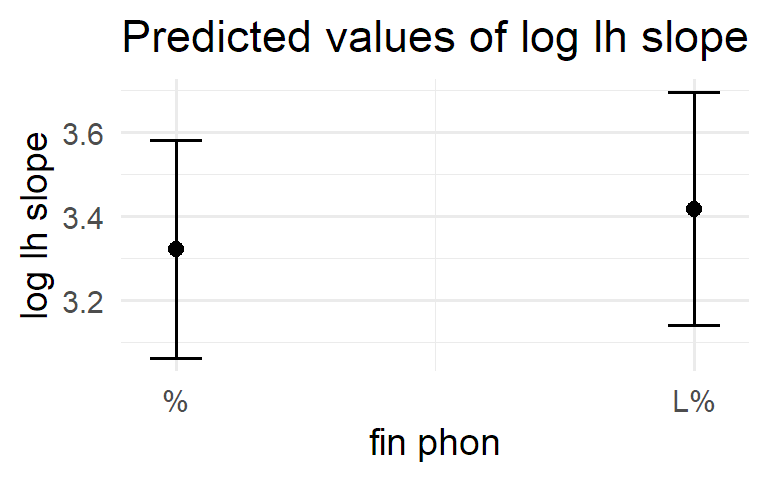

summary of model: log_lh_slope ~ foot_syls + pre_syls + fin_phon + (1 | speaker) + (1 | nuc_pre_text)

| term | estimate | conf.low | conf.high | std.error | t.value | df | p.value |
| --- | --- | --- | --- | --- | --- | --- | --- |
| (Intercept) | 3.322 | 3.02677431 | 3.61778470 | 0.132 | 25.178 | 9.64 | 4.1e-10 |
| foot_syls2 | -0.023 | -0.42182517 | 0.37511861 | 0.161 | -0.145 | 5.72 | 0.8896 |
| foot_syls3 | -0.129 | -0.19713394 | -0.06180056 | 0.034 | -3.756 | 757.94 | 2e-04 |
| foot_syls4 | -0.775 | -1.17345336 | -0.37650589 | 0.161 | -4.817 | 5.72 | 0.0034 |
| pre_syls1 | 0.274 | -0.12476467 | 0.67281198 | 0.159 | 1.726 | 5.42 | 0.1404 |
| pre_syls2 | 0.359 | -0.14874681 | 0.86746762 | 0.204 | 1.764 | 5.56 | 0.132 |
| pre_syls3 | 0.376 | -0.13220818 | 0.88403717 | 0.204 | 1.845 | 5.56 | 0.1184 |
| fin_phonL% | 0.096 | -0.01025997 | 0.20152636 | 0.054 | 1.773 | 763.27 | 0.0766 |

b0 for log_lh_slope ~ foot_syls + pre_syls + fin_phon + (1 | speaker) + (1 | nuc_pre_text)

| intercept | estimate | conf.low | conf.high | std.error | t.value | df | p.value |
| --- | --- | --- | --- | --- | --- | --- | --- |
| foot_syls1 | 3.322 | 3.027 | 3.618 | 0.132 | 25.178 | 9.64 | 4.1e-10 |
| foot_syls2 | 3.299 | 2.808 | 3.79 | 0.207 | 15.944 | 6.89 | 1.1e-06 |
| foot_syls3 | 3.193 | 2.897 | 3.488 | 0.132 | 24.206 | 9.62 | 6.0e-10 |
| foot_syls4 | 2.547 | 2.056 | 3.038 | 0.207 | 12.311 | 6.89 | 6.0e-06 |

b1 for log_lh_slope ~ foot_syls + pre_syls + fin_phon + (1 | speaker) + (1 | nuc_pre_text)

| intercept | slope | estimate | conf.low | conf.high | std.error | t.value | df | p.value |
| --- | --- | --- | --- | --- | --- | --- | --- | --- |
| foot_syls1 | foot_syls2 | -0.023 | -0.422 | 0.375 | 0.161 | -0.145 | 5.72 | 0.89 |
| foot_syls1 | foot_syls3 | -0.129 | -0.197 | -0.062 | 0.034 | -3.756 | 757.94 | 1.9e-04 |
| foot_syls1 | foot_syls4 | -0.775 | -1.173 | -0.377 | 0.161 | -4.817 | 5.72 | 0.003 |
| foot_syls2 | foot_syls3 | -0.106 | -0.505 | 0.292 | 0.162 | -0.656 | 5.83 | 0.537 |
| foot_syls2 | foot_syls4 | -0.752 | -1.15 | -0.353 | 0.161 | -4.656 | 5.80 | 0.004 |
| foot_syls3 | foot_syls4 | -0.646 | -1.044 | -0.247 | 0.162 | -3.994 | 5.82 | 0.008 |